# Applied R Project - Benchmark Analysis of do_plot() function

Goitom Sebhatu Tesfay

10/21/2021

# Benchmarking do_plot() function

#### 1. Loading rdata comparison for different files

Table1: Loading rdata comparison for different RData having different size and number of traits

| Number of Traits | File Size(MB) | Expression | Mean(ms) | Median(ms) |
| --- | --- | --- | --- | --- |
| 1 | 0.723717 | { do_plot(“gtesfay_GenomicAssistedRecurrentSelection.RData”) } | 56.71062 | 50.7093 |
| 5 | 66.426541 | { do_plot(“gtesfay_cattleDairy.RData”) } | 1424.36212 | 1401.7756 |
| 2 | 1.545645 | { do_plot(“gtesfay_Cattle.RData”) } | 47.47442 | 41.2983 |
| 1 | 2.831681 | { do_plot(“gtesfay_Sheep_breeding.RData”) } | 87.86998 | 75.0312 |
| 3 | 2.503344 | { do_plot(“gtesfay_simpleCattle.RData”) } | 141.11770 | 131.5506 |
| 2 | 3.372929 | { do_plot(“gtesfay_MoBPS_Vis21_pseudoBVE_ (1).RData”) } | 70.16732 | 64.5814 |

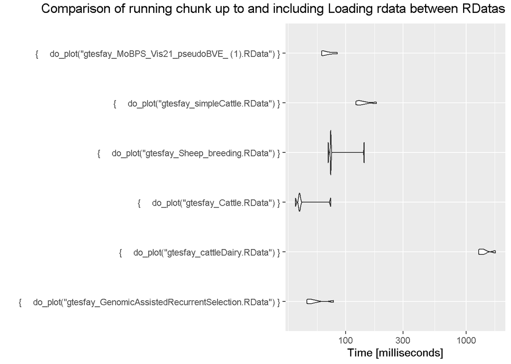

Conclusion:

#### 2. Data Initialization Step

Table2: Data Initialization Step comparison for different RData having different size and number of traits

| Number of Traits | File Size(MB) | Expression | Mean(ms) | Median(ms) |
| --- | --- | --- | --- | --- |
| 1 | 0.723717 | { do_plot(“gtesfay_GenomicAssistedRecurrentSelection.RData”) } | 143.01536 | 130.3766 |
| 5 | 66.426541 | { do_plot(“gtesfay_cattleDairy.RData”) } | 14203.00996 | 14249.2183 |
| 2 | 1.545645 | { do_plot(“gtesfay_Cattle.RData”) } | 96.14192 | 61.1630 |
| 1 | 2.831681 | { do_plot(“gtesfay_Sheep_breeding.RData”) } | 108.16706 | 115.9615 |
| 3 | 2.503344 | { do_plot(“gtesfay_simpleCattle.RData”) } | 963.94900 | 943.1778 |
| 2 | 3.372929 | { do_plot(“gtesfay_MoBPS_Vis21_pseudoBVE_ (1).RData”) } | 148.20086 | 117.6931 |

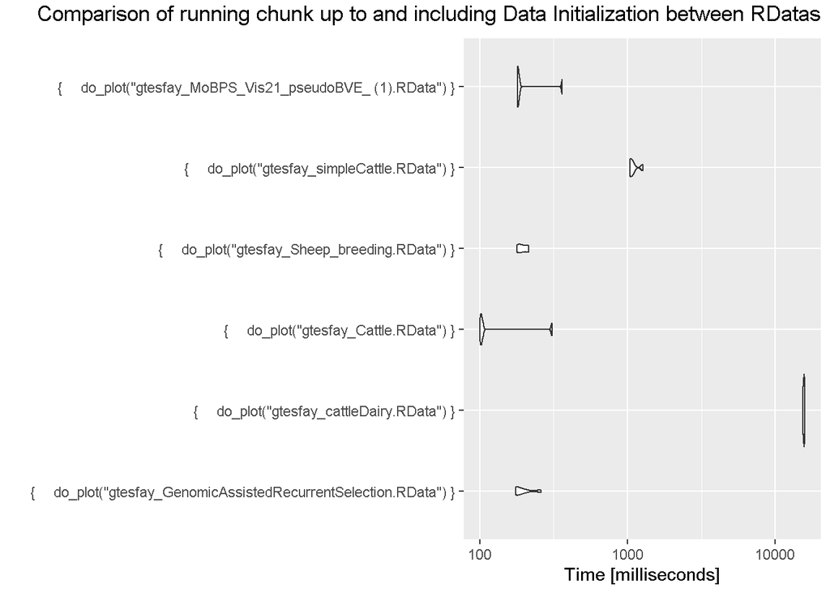

Conclusion:

#### 3. Separating traits

This benchmarking is to see the effect of the number of traits on the speed of separating the raw data provided by MOBPS.

The below table is produced by subtracting the mean and median of the running time of the data initializing step from the previous benchmarking. Observing the table the trait separation Step seem to be not affected by the size of the RData and the number of traits.

Table3: Separating traits Step comparison for different RData having different size and number of traits

| Number of Traits | File Size(MB) | Expression | Mean(ms) | Median(ms) |
| --- | --- | --- | --- | --- |
| 1 | 0.723717 | { do_plot(“gtesfay_GenomicAssistedRecurrentSelection.RData”) } | -14.40980 | -4.9375 |
| 5 | 66.426541 | { do_plot(“gtesfay_cattleDairy.RData”) } | 48.32456 | -73.9376 |
| 2 | 1.545645 | { do_plot(“gtesfay_Cattle.RData”) } | 26.00666 | 11.2268 |
| 1 | 2.831681 | { do_plot(“gtesfay_Sheep_breeding.RData”) } | -1.62750 | -1.4676 |
| 3 | 2.503344 | { do_plot(“gtesfay_simpleCattle.RData”) } | -30.49250 | -5.3730 |
| 2 | 3.372929 | { do_plot(“gtesfay_MoBPS_Vis21_pseudoBVE_ (1).RData”) } | -32.11078 | 7.2456 |

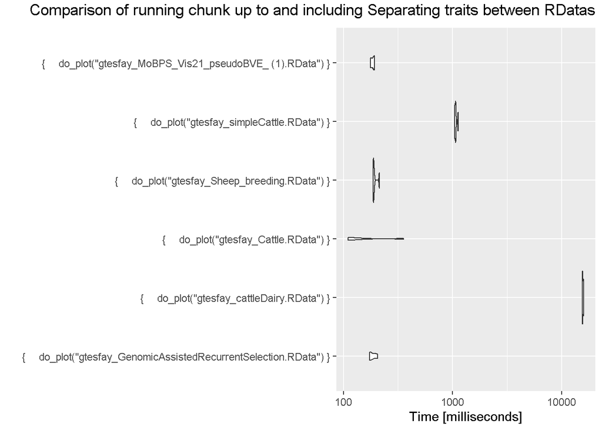

Conclusion:

The benchmark result show Separating traits Step seem to be less or not affected by the size of the RData and the number of traits. The larger the RData the same the speed of trait separation and vice versa. The more the number of traits the same the speed of trait separation and vice versa.

#### 4. Calculating Average Breeding Value of repeats

This benchmarking is to see if there is an effect on the running speed of the program, based on either the number of traits or the size of the RData, or both.

Table2: Calculating Average Breeding Value of repeats comparison for different RData having different size and number of traits

| Number of Traits | File Size(MB) | Expression | Mean(ms) | Median(ms) |
| --- | --- | --- | --- | --- |
| 1 | 0.723717 | { do_plot(“gtesfay_GenomicAssistedRecurrentSelection.RData”) } | 18.78230 | 27.9705 |
| 5 | 66.426541 | { do_plot(“gtesfay_cattleDairy.RData”) } | 1578.15600 | 1719.9808 |
| 2 | 1.545645 | { do_plot(“gtesfay_Cattle.RData”) } | -39.37974 | 15.9152 |
| 1 | 2.831681 | { do_plot(“gtesfay_Sheep_breeding.RData”) } | 26.68748 | 31.4123 |
| 3 | 2.503344 | { do_plot(“gtesfay_simpleCattle.RData”) } | 161.09834 | 153.0320 |
| 2 | 3.372929 | { do_plot(“gtesfay_MoBPS_Vis21_pseudoBVE_ (1).RData”) } | 45.90924 | 27.4830 |

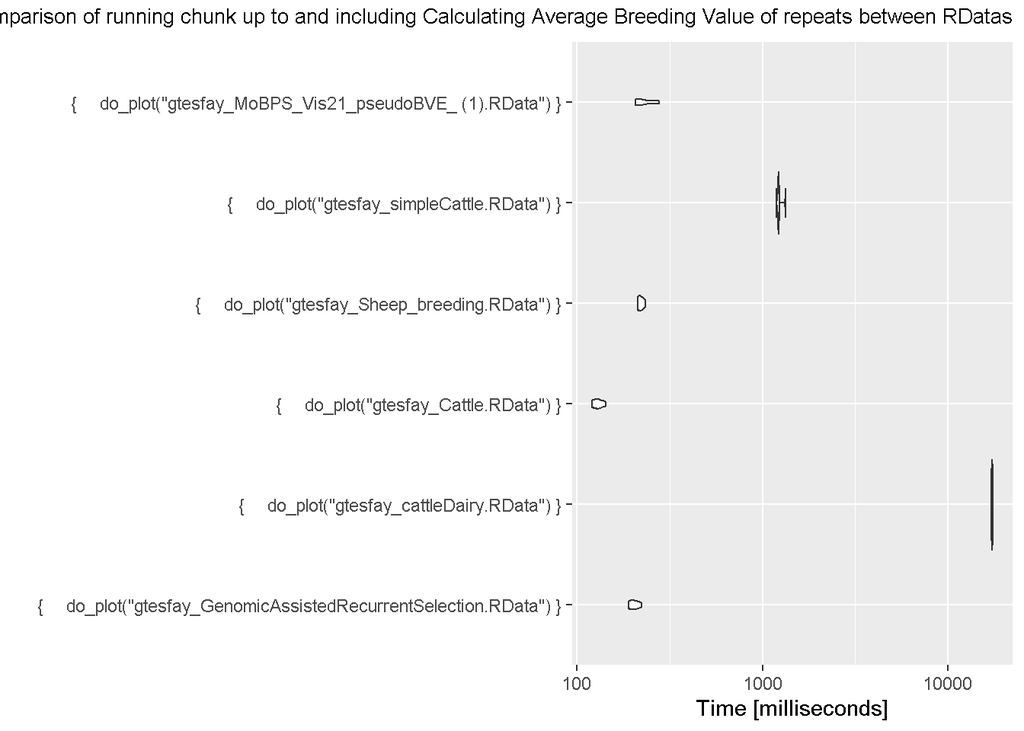

Conclusion:

The benchmark result show Calculating Average Breeding Value of repeats Step seem to be affected by the size of the RData and the number of traits. The larger the RData the slower the speed of calculating average breeding value and associated data preparation and vice versa. The more the number of traits the slower the speed of calculating average breeding value and associated data preparation and vice versa.

#### 5. Effect on speed of producing plots

This benchmarking is to see if either the number of traits or the size of the RData, or both have an effect on the speed of rendering plots.

To estimate that I modified the function as if the user choose to plot average breeding value lines plots of all cohorts, as an input I used 6 different RData with varying size and number of traits.

The below table is produced by subtracting the mean and median of the running time of the Calculating Average Breeding Value of repeats step from the previous benchmarking. Observing the table the plotting of Average Breeding Value of repeats Step seem to be highly affected by the size of the RData and the number of traits.

Table5: plotting Average Breeding Value of repeats comparison for different RData having different size and number of traits

| Number of Traits | File Size(MB) | Expression | Mean(ms) | Median(ms) |
| --- | --- | --- | --- | --- |
| 1 | 0.723717 | { do_plot(“gtesfay_GenomicAssistedRecurrentSelection.RData”) } | 1743.102 | 1745.906 |
| 5 | 66.426541 | { do_plot(“gtesfay_cattleDairy.RData”) } | 30080.063 | 31030.916 |
| 2 | 1.545645 | { do_plot(“gtesfay_Cattle.RData”) } | 2460.194 | 2445.601 |
| 1 | 2.831681 | { do_plot(“gtesfay_Sheep_breeding.RData”) } | 1920.212 | 1787.329 |
| 3 | 2.503344 | { do_plot(“gtesfay_simpleCattle.RData”) } | 4783.296 | 4586.880 |
| 2 | 3.372929 | { do_plot(“gtesfay_MoBPS_Vis21_pseudoBVE_ (1).RData”) } | 2414.819 | 2422.623 |

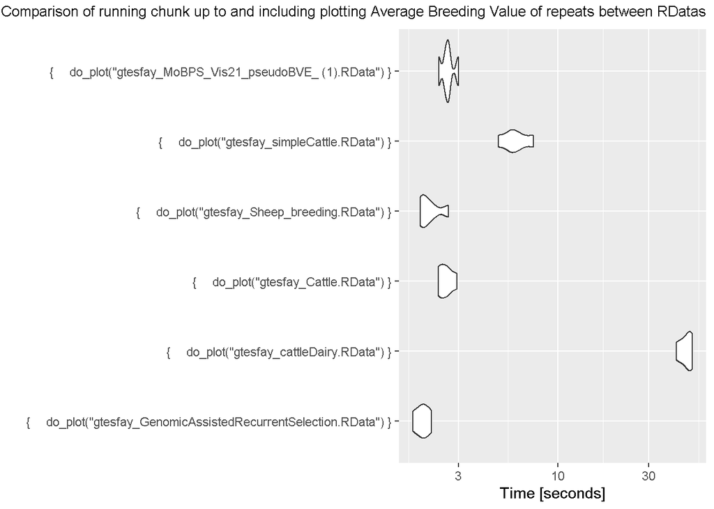

Conclusion:

The benchmark result show ploting Average Breeding Value of repeats for all cohorts Step seem to be highly affected by the size of the RData and the number of traits. The larger the RData the slower the speed of rendering plots of average breeding value of all cohorts and vice versa. The more the number of traits the slower the rendering of plots of average breeding value of all cohorts and vice versa.

#### 6. Effect on speed of Estimating inbreeding development and producing plots

This benchmarking is to see if either the number of traits or the size of the RData, or both have an effect on the speed of estimating inbreeding development and rendering line plots.

Table5: plotting estimating inbreeding development and producing plots comparison for different RData having different size and number of traits

| Number of Traits | File Size(MB) | Expression | Mean(ms) | Median(ms) |
| --- | --- | --- | --- | --- |
| 1 | 0.723717 | { do_plot(“gtesfay_GenomicAssistedRecurrentSelection.RData”) } | 12148.405 | 10775.025 |
| 5 | 66.426541 | { do_plot(“gtesfay_cattleDairy.RData”) } | 7319.314 | 7932.479 |
| 2 | 1.545645 | { do_plot(“gtesfay_Cattle.RData”) } | 15181.404 | 14093.000 |
| 1 | 2.831681 | { do_plot(“gtesfay_Sheep_breeding.RData”) } | 9093.889 | 8359.016 |
| 3 | 2.503344 | { do_plot(“gtesfay_simpleCattle.RData”) } | 7304.531 | 7459.820 |
| 2 | 3.372929 | { do_plot(“gtesfay_MoBPS_Vis21_pseudoBVE_ (1).RData”) } | 23755.193 | 24072.824 |

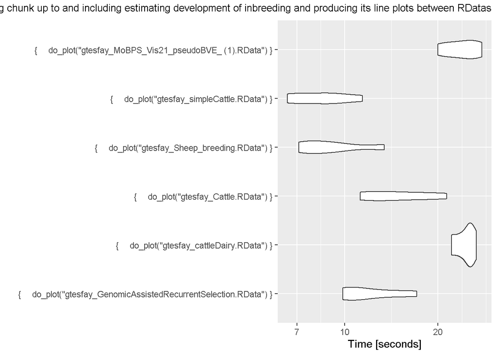

#### 7. Effect of ibd and hbd size on speed of Estimating inbreeding development and producing plots

This benchmarking is to see if the size of ibd and hbd,have an effect on the speed of estimating inbreeding development and rendering line plots. To benchmark this I choose two sets of ibd and hbd size. The first set (ibd=200 and hbd=200) and the second set (ibd=4000 and hbd=4000).

I modified the function as if the user choose for the function to estimate inbreeding and produce the two line plots showing inbreeding development across generation and across time plots either by choosing the first set (ibd=200 and hbd=200) or the second set (ibd=4000 and hbd=4000). As an input I used one RData.

The below table is produced by subtracting the mean and median of the running time of the Calculating Average Breeding Value of repeats step from the previous benchmarking. Observing the table speed of estimating inbreeding development and rendering line plots seem to be highly affected by the size of the ibd and hbd.

Table5: plotting estimating inbreeding development and producing plots comparison for different ibd and hbd size

| Number of Traits | File Size(MB) | Expression | Mean(ms) | Median(ms) |
| --- | --- | --- | --- | --- |
| 3 | 2.503344 | { do_plot(“gtesfay_simpleCattle.RData”) } | 8860.20 | 7932.604 |
| 3 | 2.503344 | { do_plot1(“gtesfay_simpleCattle.RData”) } | 72460.53 | 72316.537 |

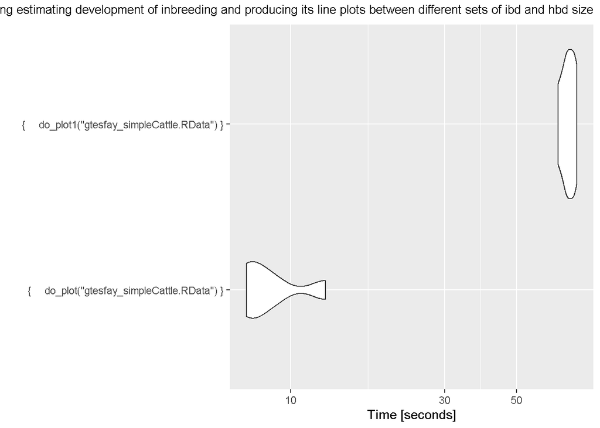

Conclusion:

The benchmark result show speed of estimating inbreeding development and rendering line plots seem to be highly affected by the size of ibd and hbd. The larger the larger the ibd and hbd the slower the speed of estimating inbreeding development and rendering line plots and vice versa.